# Practical Machine Learning Coursera-Project

Stéphane Nyombayire

Wednesday, July 21, 2015

## Data Analysis

More details about the data can be found http://groupware.les.inf.puc-rio.br/har (see the section on the Weight Lifting Exercise Dataset).

### Data

The training data for this project are available here:

https://d396qusza40orc.cloudfront.net/predmachlearn/pml-training.csv

The test data are available here:

https://d396qusza40orc.cloudfront.net/predmachlearn/pml-testing.csv

Let’s get the data from the appropriate files:

```r
training <- read.csv("pml-training.csv")
testing<- read.csv("pml-testing.csv")
dim(training); dim(testing)
```

```
## [1] 19622   160
```

```
## [1]  20 160
```

Training set has 19622 observations and 160 variables; Test set has 20 observations and 160 variables.

### Exploratory Analysis: Classes per User

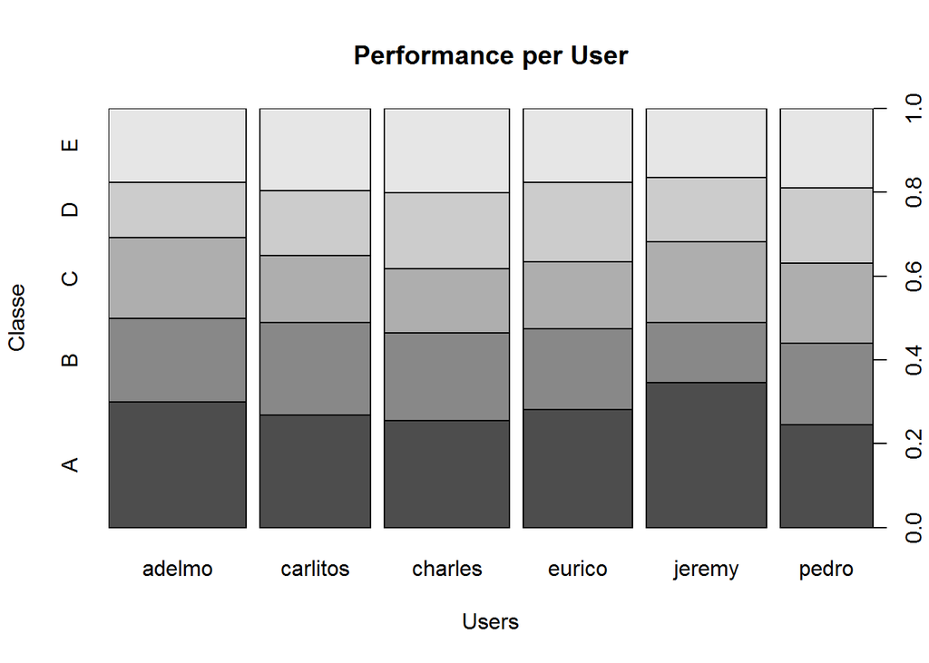

```r
plot(training$user_name, training$classe, xlab = "Users", ylab = "Classe", main = "Performance per User")
```

First we notice that all 6 users have accomplished their workout in all of the 5 categories. Category A is more prevalent for each of the user.

### Data transformation and reducing the number of variables used in the model

We first remove the first 7 columns of the data sets as they are orthogonal to our study. We applied the same transformation to the test data set

```r
training<-training[, -c(1:7)]
testing<-testing[, -c(1:7)]
```

Getting getting rid of other irrelevant variables = zero covariates, by applying near zero variables method:

```r
set.seed(1969)
nzvv <- nearZeroVar(testing)
training<-training[, -nzvv]
testing<-testing[, -nzvv]
```

There is a column difference between test and train; train has classe, test has problem_id. We’ll get rid of problem_id in test in add classe, so the 2 data sets have an identical set of variables.

```r
testing$problem_id <- NULL
testing$classe<- c(rep("A",20))
##transforming classe into a factor class for uniformity with the training set
testing$classe <- as.factor(testing$classe)
```

## Prediction Model

Our goal is to first reduce the number of predictors by using rpart and removing least important predictors. For the final list of predictors, we will run a random forest model

### Reducing the number of predictors using RPart

We will remove the predictors whose variable importance is 0

```r
modelFit <-  rpart(classe ~ ., data = training, method="class")
vi <- varImp(modelFit)
tmp<-rownames(vi)[vi$Overall>0]
trainTemp<-training[, c(tmp,"classe")]
testTemp<-testing[, c(tmp,"classe")]
```

### Model Building and Cross-validation

```r
modFit <-  randomForest(classe ~ ., data = trainTemp, importance = TRUE)
predTrain <- predict(modFit, newdata=trainTemp, type = "class")
confusionMatrix(predTrain, training$classe)$overall[1]
```

```
## Accuracy
##        1
```

Accuracy on this model is 1. Pretty accurate prediction. Let’s however use the Gini index to see if we can reduce the number of predictors.

```r
importantVariables <- importance(modFit)
summary(importantVariables[,"MeanDecreaseGini"])
```

```
##    Min. 1st Qu.  Median    Mean 3rd Qu.    Max.
##   132.2   257.1   320.2   430.9   476.6  1439.0
```

We can see a lot of variance among the predictors.

### Model - final choice

Let’s build a Random Forest model with the first 10 variables in the order of Gini index importance.

```r
indexedByGini = importantVariables[order(importantVariables[,"MeanDecreaseGini"],decreasing=TRUE),"MeanDecreaseGini"]
trainTemp = training[ , c(names(indexedByGini[1:10]), "classe")]
modelFit <- randomForest(classe ~ ., data = trainTemp, importance=TRUE)
```

Variables used:

```r
names(importance(modelFit)[,"MeanDecreaseGini"])
```

```
##  [1] "roll_belt"         "yaw_belt"          "pitch_forearm"
##  [4] "magnet_dumbbell_z" "pitch_belt"        "magnet_dumbbell_y"
##  [7] "roll_forearm"      "magnet_dumbbell_x" "roll_dumbbell"
## [10] "accel_dumbbell_y"
```

Our model’s statistics:

```r
pred<-predict(modelFit, newdata=trainTemp)
confusionMatrix(pred, trainTemp$classe)
```

```
## Confusion Matrix and Statistics
##
##           Reference
## Prediction    A    B    C    D    E
##          A 5580    0    0    0    0
##          B    0 3797    0    0    0
##          C    0    0 3422    0    0
##          D    0    0    0 3216    0
##          E    0    0    0    0 3607
##
## Overall Statistics
##
##                Accuracy : 1
##                  95% CI : (0.9998, 1)
##     No Information Rate : 0.2844
##     P-Value [Acc > NIR] : < 2.2e-16
##
##                   Kappa : 1
##  Mcnemar's Test P-Value : NA
##
## Statistics by Class:
##
##                      Class: A Class: B Class: C Class: D Class: E
## Sensitivity            1.0000   1.0000   1.0000   1.0000   1.0000
## Specificity            1.0000   1.0000   1.0000   1.0000   1.0000
## Pos Pred Value         1.0000   1.0000   1.0000   1.0000   1.0000
## Neg Pred Value         1.0000   1.0000   1.0000   1.0000   1.0000
## Prevalence             0.2844   0.1935   0.1744   0.1639   0.1838
## Detection Rate         0.2844   0.1935   0.1744   0.1639   0.1838
## Detection Prevalence   0.2844   0.1935   0.1744   0.1639   0.1838
## Balanced Accuracy      1.0000   1.0000   1.0000   1.0000   1.0000
```

And a view of our model:

```r
print(modelFit)
```

```
##
## Call:
##  randomForest(formula = classe ~ ., data = trainTemp, importance = TRUE)
##                Type of random forest: classification
##                      Number of trees: 500
## No. of variables tried at each split: 3
##
##         OOB estimate of  error rate: 1.04%
## Confusion matrix:
##      A    B    C    D    E class.error
## A 5546   16   14    4    0 0.006093190
## B   23 3709   49   16    0 0.023176192
## C    3   20 3383   15    1 0.011396844
## D    0    2   18 3192    4 0.007462687
## E    0    8    8    3 3588 0.005267535
```

By only using the top ten predictors based on the Gini index we still achieve an accuracy of 1

```r
confTable<-confusionMatrix(pred,trainTemp$classe)
errorRate<-1-sum(diag(confTable$table))/sum(confTable$table)
errorRate
```

```
## [1] 0
```

### Verification of our model

Finally, we perform the verification on the test set (which went through the same data transformations we applied to the training data set):

```r
testTemp = testing[ , c(names(indexedByGini[1:10]), "classe")]
predTest <- predict(modelFit, newdata=testTemp)
predTest
```

```
##  1  2  3  4  5  6  7  8  9 10 11 12 13 14 15 16 17 18 19 20
##  B  A  B  A  A  E  D  B  A  A  B  C  B  A  E  E  A  B  B  B
## Levels: A B C D E
```

I also ran the submission script and the prediction for the test results were at 100%